# Title of Blog Post Deliverable

#### 2.1.1.3 Uniform

Uniform mean:
$${\tfrac {1}{2}}(min+max)$$

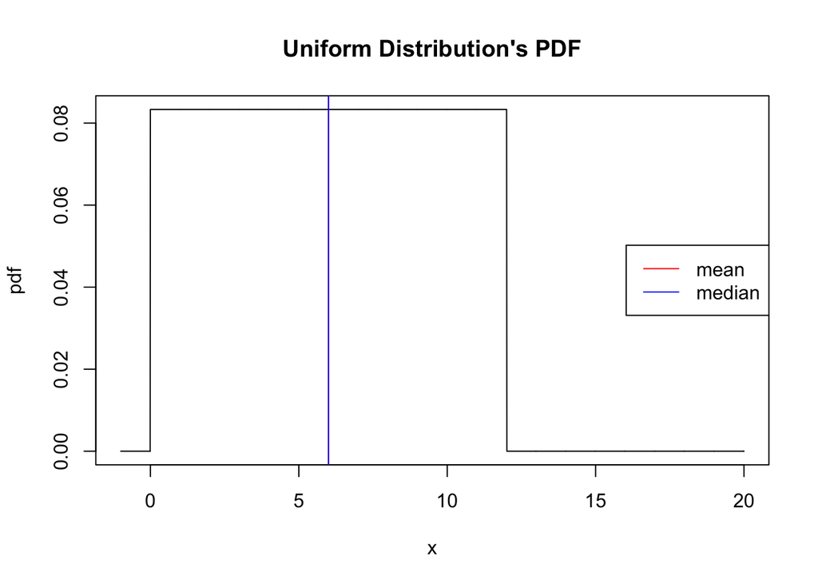

```r
x <- seq(-1,20,by=0.01)
# PDF
pdf <- dunif(x,0,12)
# CDF
cdf <- punif(x,0,12)
mean <- (0+12)/2
median <- qunif(0.5, 0,12)

#PDF
plot(x,pdf, main="Uniform Distribution's PDF", type ="l")
abline(v = mean, col = "red")
abline(v = median, col = "blue")
legend("right", c("mean","median"),col =  c("red","blue"), lty=c(1,1))
```

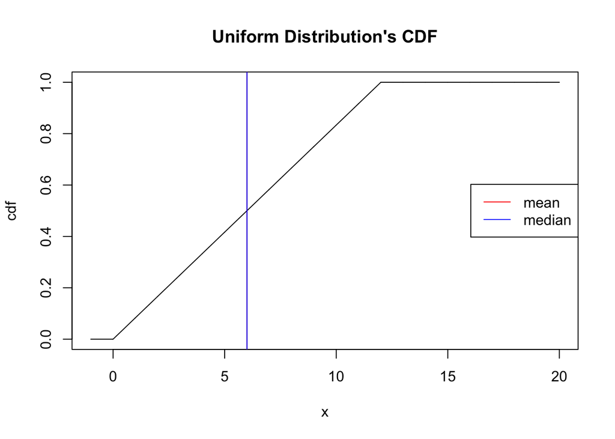

```r
#CDF
plot(x,cdf, main="Uniform Distribution's CDF", type ="l")
abline(v = mean, col = "red")
abline(v = median, col = "blue")
legend("right", c("mean","median"),col =  c("red","blue"), lty=c(1,1))
```

For the uniform distribution, the mean and the median are the same. Thus the two lines overlap.

### 2.1.2 Question 2

#### 2.1.2.1 Gamma

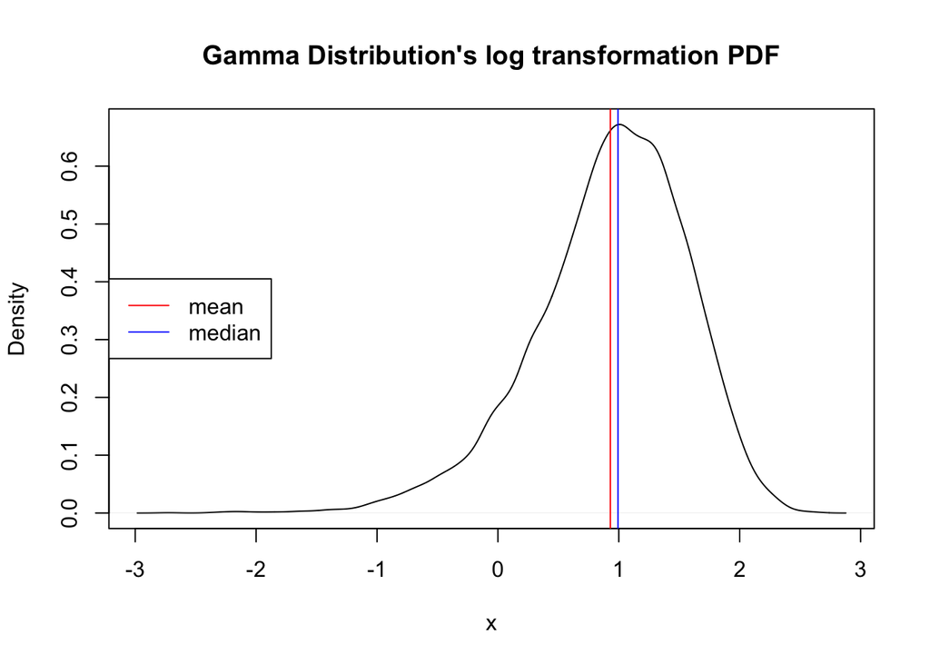

```r
x <- rgamma(10000, shape = 3, scale =1)

# PDF log transformation
Y <- log(x)
plot(density(Y),type = "l",main ="Gamma Distribution's log transformation PDF", xlab = "x")
abline(v = mean(Y), col = "red")
abline(v = median(Y), col = "blue")
legend("left",c("mean","median"), col = c("red","blue"), lty=c(1,1))
```

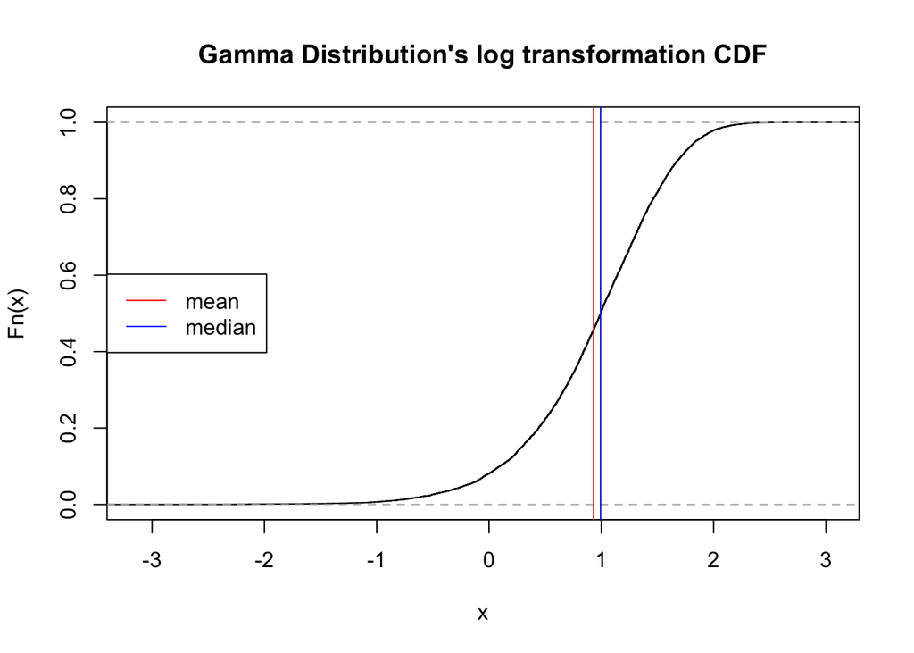

```r
# CDF log transformation
plot(ecdf(Y), main = "Gamma Distribution's log transformation CDF")
abline(v = mean(Y), col = "red")
abline(v = median(Y), col = "blue")
legend("left",c("mean","median"), col = c("red","blue"), lty=c(1,1))
```

#### 2.1.2.2 LogNormal

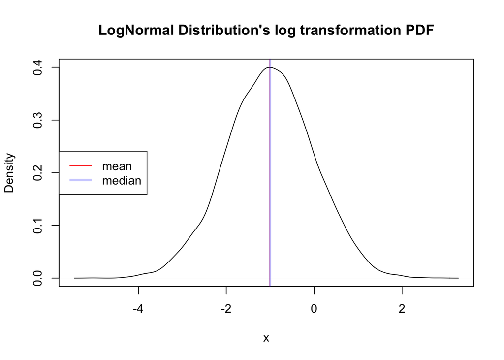

```r
x <- rlnorm(10000, -1, 1)

# PDF log transformation
Y <- log(x)
plot(density(Y),type = "l",main ="LogNormal Distribution's log transformation PDF",xlab = "x")
abline(v = mean(Y), col = "red")
abline(v = median(Y), col = "blue")
legend("left",c("mean","median"), col = c("red","blue"), lty=c(1,1))
```

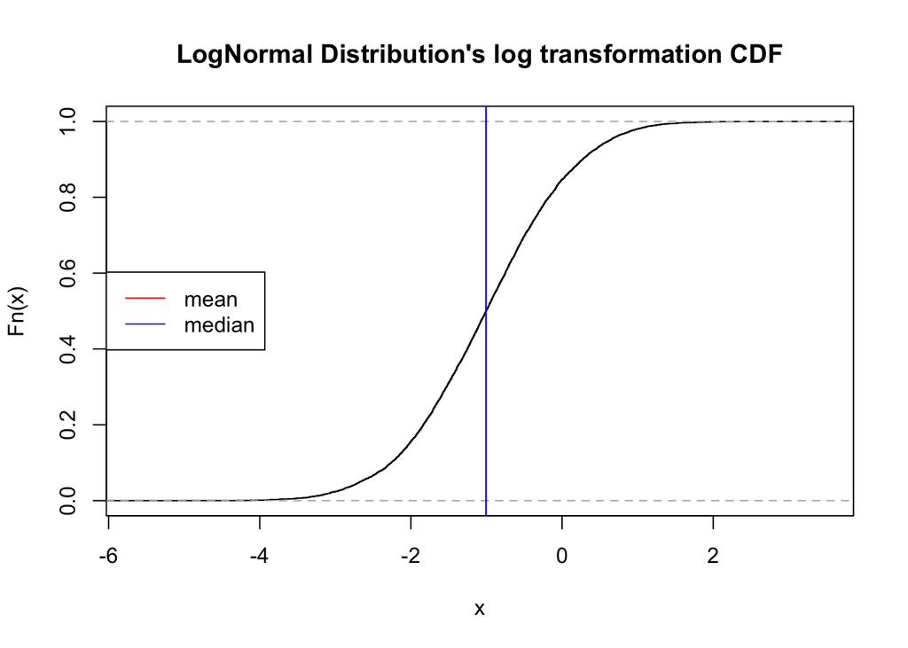

```r
# CDF log transformation
plot(ecdf(Y), main = "LogNormal Distribution's log transformation CDF")
abline(v = mean(Y), col = "red")
abline(v = median(Y), col = "blue")
legend("left",c("mean","median"), col = c("red","blue"), lty=c(1,1))
```

For the logNormal distribution, the mean and the median are the same. Thus the two lines overlap.

#### 2.1.2.3 Uniform

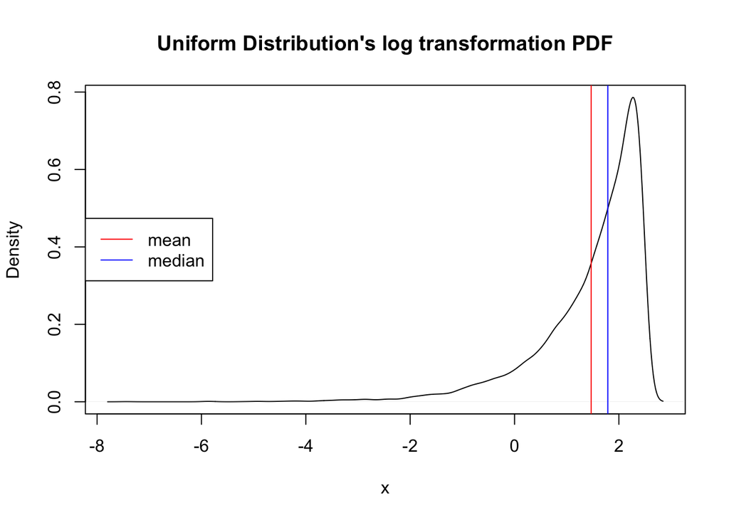

```r
x <- runif(10000, 0, 12)

# PDF log transformation
Y <- log(x)
plot(density(Y),type = "l",main ="Uniform Distribution's log transformation PDF",xlab = "x")
abline(v = mean(Y), col = "red")
abline(v = median(Y), col = "blue")
legend("left",c("mean","median"), col = c("red","blue"), lty=c(1,1))
```

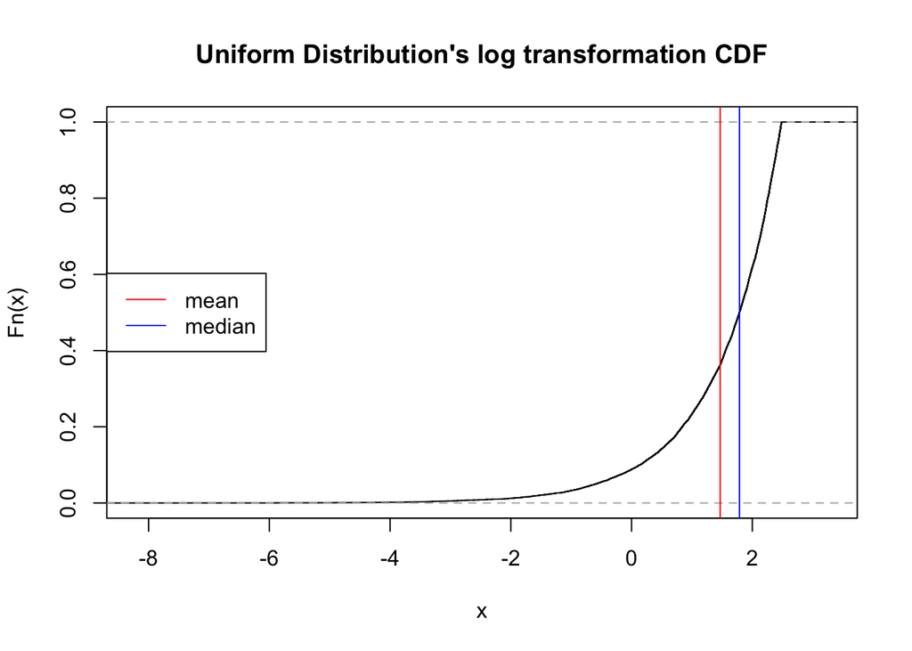

```r
# CDF log transformation
plot(ecdf(Y), main = "Uniform Distribution's log transformation CDF")
abline(v = mean(Y), col = "red")
abline(v = median(Y), col = "blue")
legend("left",c("mean","median"), col = c("red","blue"), lty=c(1,1))
```

### 2.1.3 Question 3

Arithmetic mean
$$\frac{\left(x_{1}+x_{2}+...+x_{n}\right)}{n}$$
Geometric mean
$$\left(x_{1}\cdot x_{2}\cdot...\cdot x_{n}\right)^{\frac{1}{n}}$$
How to calculate geometric mean
$$e^{\frac{\left(\log x_{1}+\log x_{2}+...+\log x_{n}\right)}{n}}=e^{\left(\frac{1}{n}\cdot\log\left(x_{1}x_{2}...x_{n}\right)\right)}=e^{\log\left(\left(x_{1}\cdot x_{2}\cdot...\cdot x_{n}\right)^{\frac{1}{n}}\right)}=\left(x_{1}\cdot x_{2}\cdot...\cdot x_{n}\right)^{\frac{1}{n}}$$

#### 2.1.3.1 Gamma

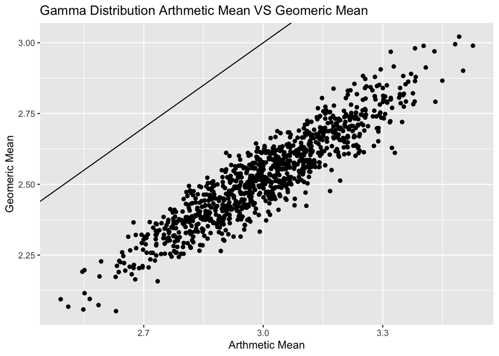

```r
# generate the sample
sample <- data.frame(replicate(1000,rgamma(100,shape=3,scale=1)))
# calculate the arthmetic and geometric mean
gamma_arthi <- rep(NA,1000)
gamma_geo <- rep(NA,1000)
for (i in seq_along(gamma_arthi)){
  gamma_arthi[i] <- mean(sample[[i]])
  gamma_geo[i] <- exp(mean(log(sample[[i]])))
}
# generate the graphic
data.frame(arthmetic = gamma_arthi,geometric = gamma_geo) %>%
  ggplot(aes(x=arthmetic,y=geometric)) +
  geom_point()+
  geom_abline(intercept = 0, slope=1)+
  labs(
    x= "Arthmetic Mean",
    y= "Geomeric Mean",
    title ="Gamma Distribution Arthmetic Mean VS Geomeric Mean "
  )
```

#### 2.1.3.2 LogNormal

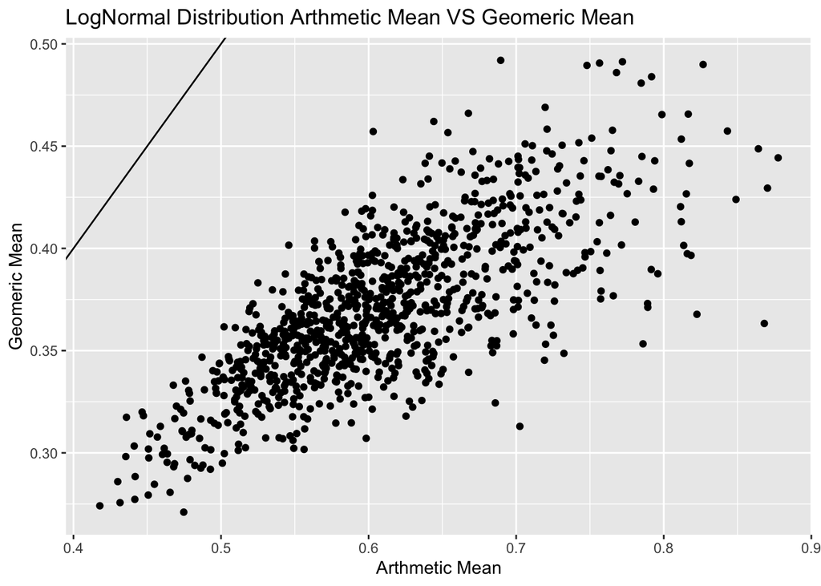

```r
# generate the sample
sample <- data.frame(replicate(1000,rlnorm(100,-1,1)))
# calculate the arthmetic and geometric mean
logNormal_arthi <- rep(NA,1000)
logNormal_geo <- rep(NA,1000)
for (i in seq_along(logNormal_arthi)){
  logNormal_arthi[i] <- mean(sample[[i]])
  logNormal_geo[i] <- exp(mean(log(sample[[i]])))
}
# generate the graphic
data.frame(arthmetic = logNormal_arthi,geometric=logNormal_geo) %>%
  ggplot(aes(x=arthmetic,y=geometric)) +
  geom_point()+
  geom_abline(intercept = 0, slope=1)+
  labs(
    x= "Arthmetic Mean",
    y= "Geomeric Mean",
    title ="LogNormal Distribution Arthmetic Mean VS Geomeric Mean "
  )
```

#### 2.1.3.3 Uniform

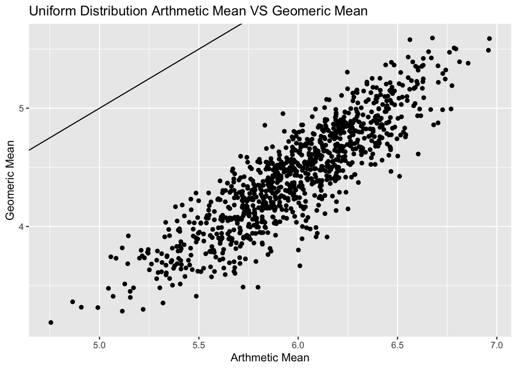

```r
# generate the sample
sample <- data.frame(replicate(1000,runif(100,0,12)))
# calculate the arthmetic and geometric mean
uniform_arthi <- rep(NA,1000)
uniform_geo <- rep(NA,1000)
for (i in seq_along(uniform_arthi)){
  uniform_arthi[i] <- mean(sample[[i]])
  uniform_geo[i] <- exp(mean(log(sample[[i]])))
}
# generate the graphic
data.frame(arthmetic = uniform_arthi,geometric = uniform_geo) %>%
  ggplot(aes(x=arthmetic,y=geometric)) +
  geom_point()+
  geom_abline(intercept = 0, slope=1)+
  labs(
    x= "Arthmetic Mean",
    y= "Geomeric Mean",
    title ="Uniform Distribution Arthmetic Mean VS Geomeric Mean "
  )
```

### 2.1.4 Question 4

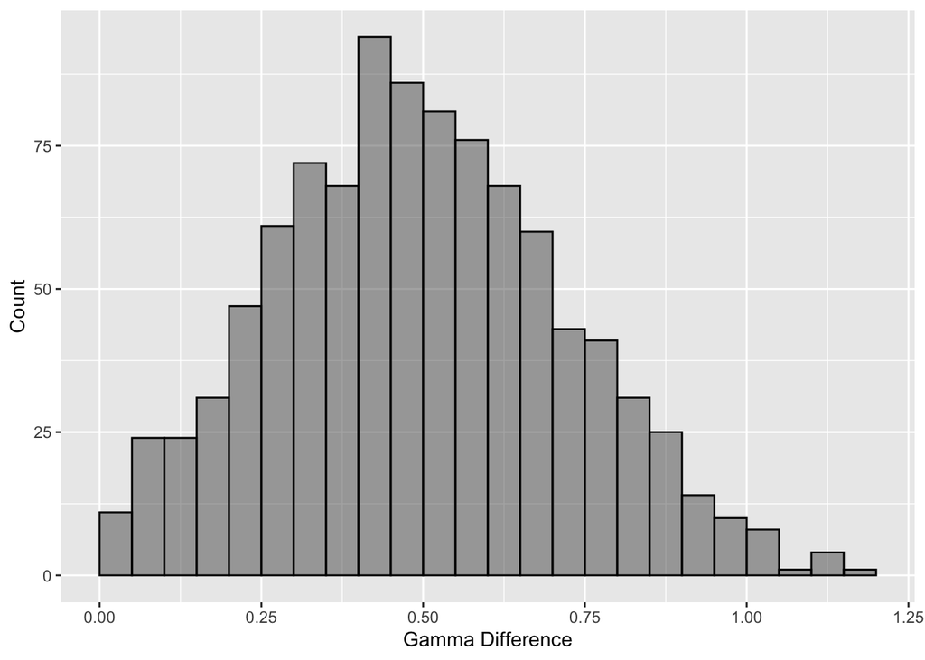

```r
# set seed
set.seed(2)
# gamma arithmetic mean
gamma_arthi_value <- replicate(1000,mean(rgamma(100,shape=3,scale=1)))
# gamma geometric mean
gamma_geo_value <- replicate(1000,exp(mean(log(rgamma(100,shape=3,scale=1)))))
# find difference
gamma_diff = gamma_arthi_value-gamma_geo_value
# draw the figure
data.frame(gamma_diff) %>%
  ggplot(aes(x=gamma_diff))+
  geom_histogram(bins=30,
                 col = "black",
                 alpha=0.5,
                 breaks = seq(0,1.2,by = 0.05)) +
  labs(
    x="Gamma Difference",
    y="Count"
  )
```

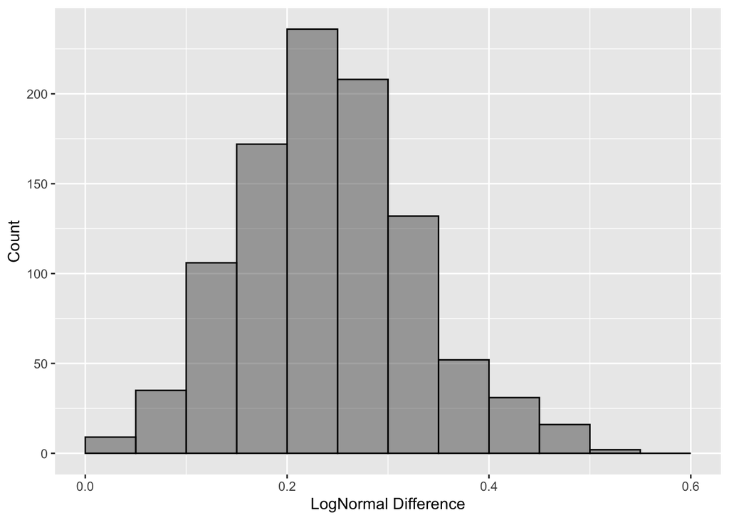

```r
# logNormal arithmetic mean
logNormal_arthi_value <- replicate(1000,mean(rlnorm(100,-1,1)))
# logNormal geometric mean
logNormal_geo_value <- replicate(1000,exp(mean(log(rlnorm(100,-1,1)))))
# find the difference
logNormal_diff = logNormal_arthi_value-logNormal_geo_value
# draw the figure
data.frame(logNormal_diff) %>%
  ggplot(aes(x=logNormal_diff))+
  geom_histogram(bins=30,
                 col = "black",
                 alpha=0.5,
                 breaks=seq(0,0.6,by=0.05))+
  labs(
    x="LogNormal Difference",
    y="Count"
  )
```

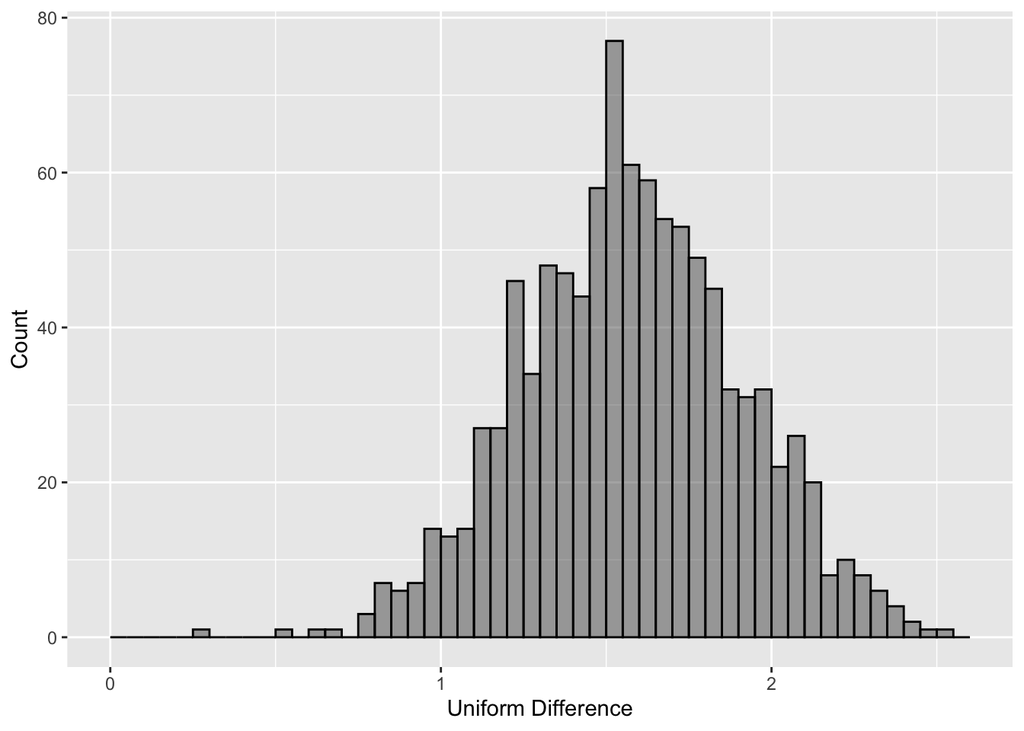

```r
# uniform arithmetic mean
uniform_arthi_value <- replicate(1000,mean(runif(300,0,12)))
# uniform geometric mean
uniform_geo_value <- replicate(1000,exp(mean(log(runif(300,0,12)))))
# find the difference
uniform_diff = uniform_arthi_value-uniform_geo_value
# draw the figure
data.frame(uniform_diff) %>%
  ggplot(aes(x=uniform_diff))+
  geom_histogram(bins=30,
                 col = "black",
                 alpha=0.5,
                 breaks=seq(0,2.6,by=0.05))+
  labs(
    x="Uniform Difference",
    y="Count"
  )
```

For all three figures, the X-axis is the difference between arithmetic mean and geometric mean, the Y-axis id the count of each difference. From all three figures, arithmetic mean is always larger or equal to geometric mean.
Proof of this conclusion: suppose calculate the arithmetic mean and geometric mean of two values a and b.
Arithmetic mean
$$\frac{\left(a+b\right)}{2}$$
Geometric mean
$$\sqrt{ab}$$
Arithmetic mean^2 - Geometric mean^2
$$\left(\frac{\left(a+b\right)}{2}\right)^{2}\ \ -\ \left(\sqrt{ab}\right)^{2}=\frac{\left(a^{2}+2ab+b^{2}\right)}{4}-\frac{4ab}{4}=\frac{\left(a^{2}-2ab+b^{2}\right)}{4}=\frac{\left(a-b\right)^{2}}{4}\ge0$$

## 2.2 Part 3

Start from Part 1 Question 1 and 2: Gamma distribution:
$$log(E[x]) = log(3) = 1.09861228867 > E[log(x)] = 0.922784335098$$
LogNormal distribution:
$$log(E[x]) = log(0.606462351047) = −0.500112628292
> E[log(x)] = -1.00000533767$$
Uniform distribution:
$$log(E[x]) = log(6) = 1.79175946923
> E[log(x)] = 1.48490664979$$
Assume Relationship:
$$E[log(X)] ≤ log(E(X))$$
Proof of assumption
According to the Jensens inequality: for any concave function f,
$$E(f(X)) ≤ f(E(X))$$
A function is concave if it’s second derivative is negative
Proof f: x -> log(x) is a concave function
$$f'' = (log(x))'' = (\frac{1}{x})' = -\frac{1}{x^2} <0$$